# ANALYSIS part of the Exercise Set 3

## *1&2. Reading the joined student alcohol consumption data into R and exploring it*

```r
library(dplyr)
joined_data<-read.table("Joined student alcohol consumption data.txt", header=T)
dim(joined_data)
```

```
## [1] 382  35
```

```r
glimpse(joined_data)
```

```
## Observations: 382
## Variables: 35
## $ school     <fct> GP, GP, GP, GP, GP, GP, GP, GP, GP, GP, GP, GP, GP,...
## $ sex        <fct> F, F, F, F, F, M, M, F, M, M, F, F, M, M, M, F, F, ...
## $ age        <int> 18, 17, 15, 15, 16, 16, 16, 17, 15, 15, 15, 15, 15,...
## $ address    <fct> U, U, U, U, U, U, U, U, U, U, U, U, U, U, U, U, U, ...
## $ famsize    <fct> GT3, GT3, LE3, GT3, GT3, LE3, LE3, GT3, LE3, GT3, G...
## $ Pstatus    <fct> A, T, T, T, T, T, T, A, A, T, T, T, T, T, A, T, T, ...
## $ Medu       <int> 4, 1, 1, 4, 3, 4, 2, 4, 3, 3, 4, 2, 4, 4, 2, 4, 4, ...
## $ Fedu       <int> 4, 1, 1, 2, 3, 3, 2, 4, 2, 4, 4, 1, 4, 3, 2, 4, 4, ...
## $ Mjob       <fct> at_home, at_home, at_home, health, other, services,...
## $ Fjob       <fct> teacher, other, other, services, other, other, othe...
## $ reason     <fct> course, course, other, home, home, reputation, home...
## $ nursery    <fct> yes, no, yes, yes, yes, yes, yes, yes, yes, yes, ye...
## $ internet   <fct> no, yes, yes, yes, no, yes, yes, no, yes, yes, yes,...
```

[output cut: 22 more lines]

The dataset “joined_data”" includes info on student achievement in secondary education of two Portuguese schools. The data variables (35) include student grades, demographic, social and school related features) and it was collected by using school reports and questionnaires. Two datasets are provided regarding the performance in two distinct subjects: Mathematics (mat) and Portuguese language (por).

## *3. Choosing variables and study hypotheses.*

The purpose of my analysis is to study the relationships between high/low alcohol consumption and some of the other variables in the data. To do this, I choose the following 4 variables: 1. sex (hypothesis is that boys in average consume more alcohol an would be more often high-users), 2. age (older students would be consuming more and more of older ones would be found in high-users’ group), 3. internet (those who have internet would be high-users or consume more) and 4.absences (the idea is that the more absences would be associated with high-users.

## *4. The distrubutions of the chosen variables and what about my study hypotheses?*

```r
joined_data %>% group_by(sex) %>% summarise(count = n())
```

```
## # A tibble: 2 x 2
##   sex   count
##   <fct> <int>
## 1 F       198
## 2 M       184
```

```r
joined_data %>% group_by(age) %>% summarise(count = n())
```

```
## # A tibble: 7 x 2
##     age count
##   <int> <int>
## 1    15    81
## 2    16   107
## 3    17   100
## 4    18    81
## 5    19    11
## 6    20     1
## 7    22     1
```

```r
joined_data %>% group_by(internet) %>% summarise(count = n())
```

```
## # A tibble: 2 x 2
##   internet count
##   <fct>    <int>
## 1 no          58
## 2 yes        324
```

```r
joined_data %>% group_by(absences) %>% summarise(count = n())
```

```
## # A tibble: 26 x 2
##    absences count
##       <int> <int>
##  1        0    65
##  2        1    51
##  3        2    58
##  4        3    41
##  5        4    36
##  6        5    22
##  7        6    21
##  8        7    12
##  9        8    20
## 10        9    12
## # ... with 16 more rows
```

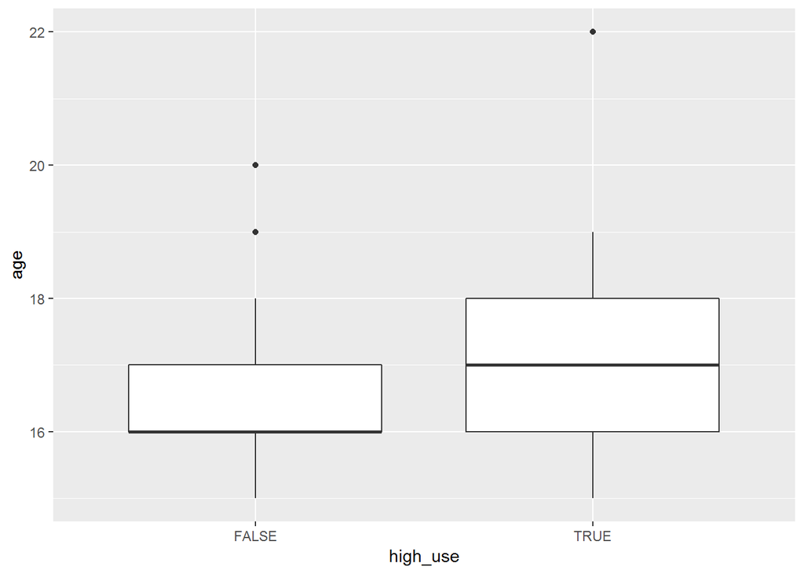

```r
library(ggplot2)
g1 <- ggplot(joined_data, aes(x = high_use, y = age))
g1 + geom_boxplot() + ylab("age")
```

The hypothesis about age looks like correct one: high-users are older in average.

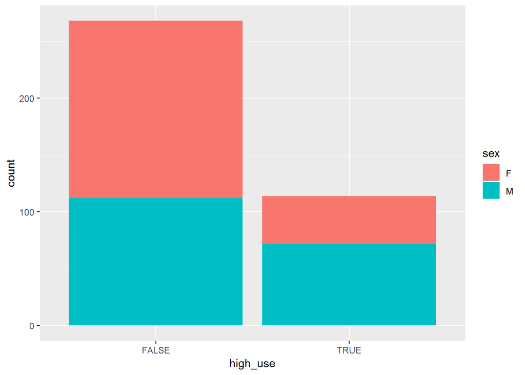

```r
library(ggplot2)
g1 <- ggplot(joined_data, aes(high_use))
g1 + geom_bar(aes(fill=sex))
```

Hypothesis about sex seems to be correct, too: in the high-users group there seems to be more boys than girls.

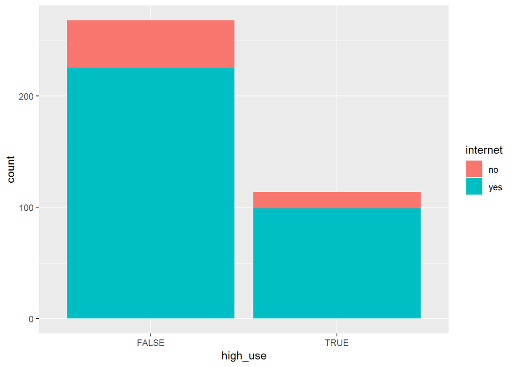

```r
library(ggplot2)
g1 <- ggplot(joined_data, aes(high_use))
g1 + geom_bar(aes(fill=internet))
```

Here it is not so obvious: it looks like in the high-users there are more of those who have internet, but this relationship is no so obvious and requires testing.

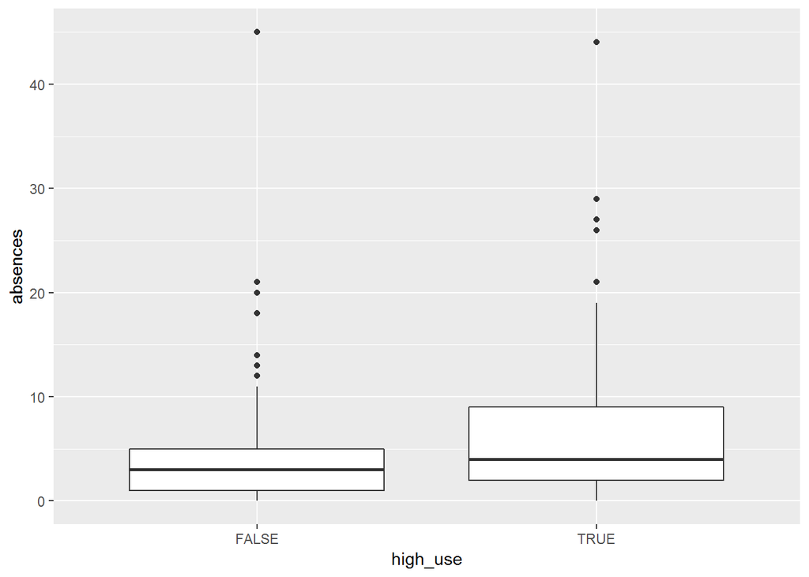

```r
library(ggplot2)
g1 <- ggplot(joined_data, aes(x = high_use, y = absences))
g1 + geom_boxplot() + ylab("absences")
```

In case of absences we need to do calculations: it is not anymore obvious, though it seems that higher number of absences are indeed observed in the group of high-users.